# Анализ сервиса аренды самокатов GoFast

## Введение

Я являюсь аналитиком популярного сервиса аренды самокатов GoFast. Мне передали данные о некоторых пользователях из нескольких городов, а также об их поездках. Необходимо проанализировать данные и проверить некоторые гипотезы, которые могут помочь бизнесу вырасти. Чтобы совершать поездки по городу, пользователи сервиса GoFast пользуются мобильным приложением. Сервисом можно пользоваться:

```
• без подписки
    ○ абонентская плата отсутствует;
    ○ стоимость одной минуты поездки — 8 рублей;
    ○ стоимость старта (начала поездки) — 50 рублей;

• с подпиской Ultra
    ○ абонентская плата — 199 рублей в месяц;
    ○ стоимость одной минуты поездки — 6 рублей;
    ○ стоимость старта — бесплатно.
```

**Описание данных:**

**1. Пользователи — users_go.csv**

- user_id — уникальный идентификатор пользователя
- name — имя пользователя
- age — возраст
- city — город
- subscription_type — тип подписки (free, ultra)

**2. Поeздки — rides_go.csv**

- user_id — уникальный идентификатор пользователя
- distance — расстояние, которое пользователь проехал в текущей сессии (в метрах)
- duration — продолжительность сессии (в минутах) — время с того момента, как пользователь нажал кнопку «Начать поездку» до момента, как он нажал кнопку «Завершить поездку»
- date — дата совершения поездки

**3. Подписки — subscriptions_go.csv**

- subscription_type — тип подписки
- minute_price — стоимость одной минуты поездки по данной подписке
- start_ride_price — стоимость начала поездки
- subscription_fee — стоимость ежемесячного платежа

**Цель проекта:** проверить три гипотезы, которые могут помочь бизнесу вырасти

**Задачи проекта:**

1. загрузка и предобработка данных
2. исследовательский анализ
3. проверка гипотез

```python
pip install missingno
```

```python
import pandas as pd
import matplotlib.pyplot as plt
import seaborn as sns
import numpy as np
import missingno as msno
from scipy import stats as st
```

## Загрузка данных

```python
try:
    data_users = pd.read_csv('/datasets/users_go.csv')
except:
    data_users = pd.read_csv('https://code.s3.yandex.net/datasets/users_go.csv')
try:
    data_riders = pd.read_csv('/datasets/rides_go.csv', parse_dates=['date'], dayfirst=True)
except:
    data_riders = pd.read_csv('https://code.s3.yandex.net/datasets/rides_go.csv', parse_dates=['date'], dayfirst=True)
try:
    data_sub = pd.read_csv('/datasets/subscriptions_go.csv')
except:
    data_sub = pd.read_csv('https://code.s3.yandex.net/datasets/subscriptions_go.csv')
```

```python
datasets = {'data_users': data_users, 'data_riders': data_riders, 'data_sub': data_sub}

for name, dataset in datasets.items():
    print(f"Название датасета: {name}")
    display(dataset.head())
    print(f"Информация о данных:")
    dataset.info()
    print('*'*70)
    print(f"Дубликаты в данных: {dataset.duplicated().sum()}")
    print('*'*70)
    print(f"Пропуски в данных: {dataset.isna().sum()}")
    print('*'*70)
```

```
Название датасета: data_users
```

|  | user_id | name | age | city | subscription_type |
| --- | --- | --- | --- | --- | --- |
| 0 | 1 | Кира | 22 | Тюмень | ultra |
| 1 | 2 | Станислав | 31 | Омск | ultra |
| 2 | 3 | Алексей | 20 | Москва | ultra |
| 3 | 4 | Константин | 26 | Ростов-на-Дону | ultra |
| 4 | 5 | Адель | 28 | Омск | ultra |

```
Информация о данных:
<class 'pandas.core.frame.DataFrame'>
RangeIndex: 1565 entries, 0 to 1564
Data columns (total 5 columns):
 #   Column             Non-Null Count  Dtype
---  ------             --------------  -----
 0   user_id            1565 non-null   int64
 1   name               1565 non-null   object
 2   age                1565 non-null   int64
 3   city               1565 non-null   object
 4   subscription_type  1565 non-null   object
dtypes: int64(2), object(3)
memory usage: 61.3+ KB
Дубликаты в данных: 31
Пропуски в данных: user_id              0
name                 0
age                  0
city                 0
subscription_type    0
dtype: int64
Название датасета: data_riders
```

|  | user_id | distance | duration | date |
| --- | --- | --- | --- | --- |
| 0 | 1 | 4409.919140 | 25.599769 | 2021-01-01 |
| 1 | 1 | 2617.592153 | 15.816871 | 2021-01-18 |
| 2 | 1 | 754.159807 | 6.232113 | 2021-04-20 |
| 3 | 1 | 2694.783254 | 18.511000 | 2021-08-11 |
| 4 | 1 | 4028.687306 | 26.265803 | 2021-08-28 |

```
Информация о данных:
<class 'pandas.core.frame.DataFrame'>
RangeIndex: 18068 entries, 0 to 18067
Data columns (total 4 columns):
 #   Column    Non-Null Count  Dtype
---  ------    --------------  -----
 0   user_id   18068 non-null  int64
 1   distance  18068 non-null  float64
 2   duration  18068 non-null  float64
 3   date      18068 non-null  datetime64[ns]
dtypes: datetime64[ns](1), float64(2), int64(1)
memory usage: 564.8 KB
Дубликаты в данных: 0
Пропуски в данных: user_id     0
distance    0
duration    0
date        0
dtype: int64
Название датасета: data_sub
```

|  | subscription_type | minute_price | start_ride_price | subscription_fee |
| --- | --- | --- | --- | --- |
| 0 | free | 8 | 50 | 0 |
| 1 | ultra | 6 | 0 | 199 |

```
Информация о данных:
<class 'pandas.core.frame.DataFrame'>
RangeIndex: 2 entries, 0 to 1
Data columns (total 4 columns):
 #   Column             Non-Null Count  Dtype
---  ------             --------------  -----
 0   subscription_type  2 non-null      object
 1   minute_price       2 non-null      int64
 2   start_ride_price   2 non-null      int64
 3   subscription_fee   2 non-null      int64
dtypes: int64(3), object(1)
memory usage: 192.0+ bytes
Дубликаты в данных: 0
Пропуски в данных: subscription_type    0
minute_price         0
start_ride_price     0
subscription_fee     0
dtype: int64
```

## Предобработка данных

```python
for name, dataset in datasets.items():
    print(f"\033[1mНазвание датасета: {name}\033[0m")
    print(f"\033[1mКоличество уникальных значений:\033[0m \n {dataset.value_counts().sort_values(ascending=False)}")
    print('*'*70)
```

```
Название датасета: data_users
Количество уникальных значений:
 user_id  name        age  city            subscription_type
209      Андрей      23   Омск            ultra                2
1237     Евгения     23   Тюмень          free                 2
807      Александр   28   Екатеринбург    free                 2
204      Руслан      30   Пятигорск       ultra                2
403      Полина      19   Сочи            ultra                2
                                                              ..
1523     Святослав   26   Ростов-на-Дону  free                 1
1525     Ирина       21   Омск            free                 1
1526     Александра  23   Омск            free                 1
1527     Захар       24   Омск            free                 1
1534     Альберт     25   Краснодар       free                 1
Length: 1534, dtype: int64
Название датасета: data_riders
Количество уникальных значений:
 user_id  distance     duration   date
1        748.690645   15.041884  2021-11-22    1
         4031.020195  17.674448  2021-12-14    1
         2720.609748  9.529463   2021-12-22    1
         2770.890808  16.650138  2021-10-09    1
         2842.118050  23.117468  2021-11-06    1
                                              ..
1534     3214.021065  18.343604  2021-06-18    1
         3434.290912  14.366248  2021-04-29    1
         3644.708038  20.289416  2021-08-08    1
         3781.098080  19.822962  2021-11-04    1
         4928.173852  22.560373  2021-09-13    1
Length: 18068, dtype: int64
Название датасета: data_sub
Количество уникальных значений:
 subscription_type  minute_price  start_ride_price  subscription_fee
free               8             50                0                   1
ultra              6             0                 199                 1
dtype: int64
```

```python
#удаляем дубликаты и проверяем
for name, dataset in datasets.items():
    dataset.drop_duplicates(inplace=True)
    print(f"\033[1mНазвание датасета: {name}\033[0m")
    print(f"\033[1mОсталось дубликатов:\033[0m \n {dataset.duplicated().sum()}")
    print('*'*70)
```

```
Название датасета: data_users
Осталось дубликатов:
 0
Название датасета: data_riders
Осталось дубликатов:
 0
Название датасета: data_sub
Осталось дубликатов:
 0
```

```python
#проверим, за какой период в годах представлены данные
data_riders['date'].dt.year.unique()
```

```
array([2021])
```

Видим, что данные собраны лишь за 2021 год. Поэтому далее добавим столбец с месяцами 2021 года.

```python
#добавляем столбец с номером месяца
data_riders['month'] = data_riders['date'].dt.month
#проверяем
data_riders['month'].unique()
```

```
array([ 1,  4,  8, 10, 11, 12,  3,  6,  7,  2,  5,  9])
```

```python
#Рассмотрим подробнее данные о продолжительности поездок
data_riders['duration'].describe()
```

```
count    18068.000000
mean        17.805011
std          6.091051
min          0.500000
25%         13.597563
50%         17.678395
75%         21.724800
max         40.823963
Name: duration, dtype: float64
```

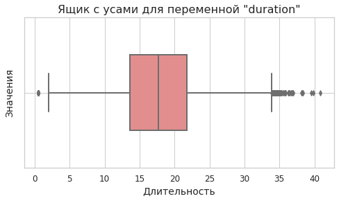

```python
# Устанавливаем стиль seaborn
sns.set(style="whitegrid")

# Создаем ящик с усами
plt.figure(figsize=(8, 4))
sns.boxplot(x=data_riders['duration'], color='lightcoral', width=0.5, linewidth=2)

# Настраиваем параметры графика
plt.title('Ящик с усами для переменной "duration"', fontsize=16)
plt.xlabel('Длительность', fontsize=14)
plt.ylabel('Значения', fontsize=14)
plt.xticks(fontsize=12)
plt.yticks(fontsize=12)
plt.grid(True, axis='both')

# Показываем график
plt.show()
```

Как мы видим, в столбце duration (продолжительность сессии) присутствует много выбросов. Однако, стоит заметить, что избавиться от них мы не можем, чтобы не навредить процессу исследования и не испортить финальные выводы. Нам важны все данные о продолжительности сессии.

**Вывод по предобработке:** мы удалили дубликаты, которые были лишь в одном датасете; посмотрели наличие пропусков - их не выявлено; добавили новый столбец в data_riders с номером месяца поездки; обнаружили наличие выбросов в данных о продолжительности сессии.

## Исследовательский анализ данных

**Частота встречаемости городов**

```python
# Сначала найдем сумму встречаемости всех городов
data_users['city'].value_counts().sum()
```

```
1534
```

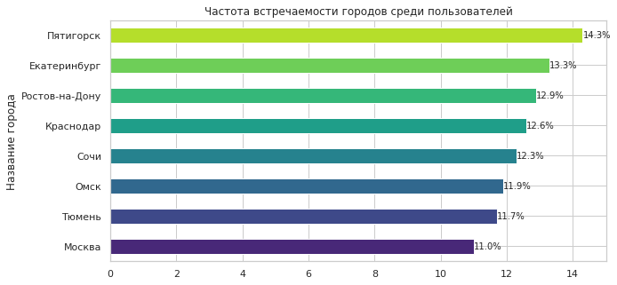

```python
# Определим саму частоту по каждому городу
plt.figure(figsize=(10, 5))
# Генерируем частоты и рисуем столбчатую диаграмму
city_frequency = data_users['city'].value_counts() / len(data_users['city']) * 100
city_frequency = round(city_frequency, 1)
sns.set(style="whitegrid")

# Рисуем столбчатую диаграмму
freq = city_frequency.sort_values().plot(
    kind='barh',
    color=sns.color_palette('viridis', len(city_frequency)),
    figsize=(10, 5),
    title='Частота встречаемости городов среди пользователей',
    xlabel='Название города'
)

# Добавляем значения на столбцах
for index, value in enumerate(city_frequency.sort_values()):
    plt.text(value, index, f'{value}%', ha='left', va='center', fontsize=10)

plt.show()
```

```python
round(city_frequency).max() - round(city_frequency).min()
```

```
3.0
```

Количество пользователей в разных городах различается несущественно (лишь на несколько процентов). Так, разница между городом с наибольшим числом пользователей и городом с наименьшим числом пользователей составляет всего лишь 3%.

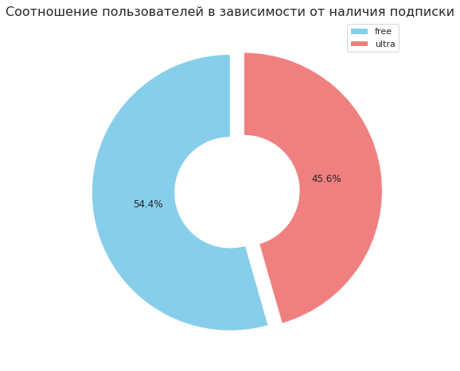

```python
# Создаем фигуру и оси
plt.figure(figsize=(8, 8))

# Генерируем данные
tariff_type = data_users['subscription_type'].value_counts()

# Рисуем круговую диаграмму
wedgeprops = {"linewidth": 1, 'width': 0.6, "edgecolor": "w"}
colors = ['skyblue', 'lightcoral']
explode = (0, 0.1)  # Выделяем один из сегментов

tariff_type.plot(
    kind='pie',
    autopct='%1.1f%%',
    startangle=90,
    explode=explode,
    colors=colors,
    wedgeprops=wedgeprops,
    labels=None
)

# Добавляем метки
plt.gca().set_aspect('equal')
plt.legend(labels=tariff_type.index, loc='upper right')
plt.title('Соотношение пользователей в зависимости от наличия подписки', fontsize=16)
plt.ylabel('')

plt.show()
```

```python
data_users['age'].describe()
```

```
count    1534.000000
mean       24.903520
std         4.572367
min        12.000000
25%        22.000000
50%        25.000000
75%        28.000000
max        43.000000
Name: age, dtype: float64
```

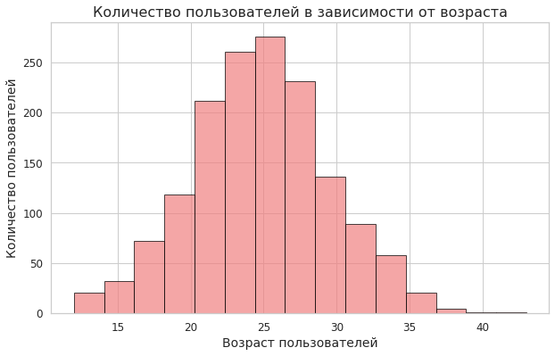

```python
plt.figure(figsize=(10, 6))
# Рисуем гистограмму
data_users['age'].hist(bins=15, edgecolor='black', color='lightcoral', alpha=0.7)
plt.title('Количество пользователей в зависимости от возраста', fontsize=16)
plt.xlabel('Возраст пользователей', fontsize=14)
plt.ylabel('Количество пользователей', fontsize=14)
plt.xticks(fontsize=12)
plt.yticks(fontsize=12)
plt.grid(True, axis='both')

plt.show()
```

```python
# Определим расстояние, которое пользователь преодолел за одну поездку
data_riders['distance'].describe()
```

```
count    18068.000000
mean      3070.659976
std       1116.831209
min          0.855683
25%       2543.226360
50%       3133.609994
75%       3776.222735
max       7211.007745
Name: distance, dtype: float64
```

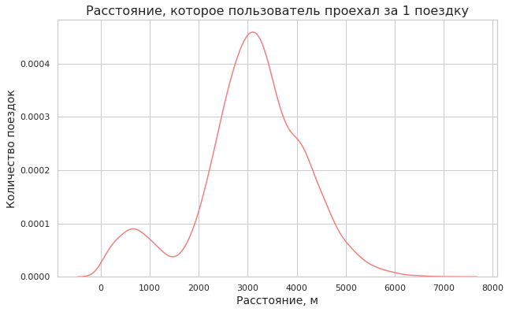

```python
plt.figure(figsize=(10, 6))
sns.kdeplot(data_riders['distance'], color='lightcoral')

# Добавляем заголовок и подписи к осям
plt.title('Расстояние, которое пользователь проехал за 1 поездку', fontsize=16)
plt.xlabel('Расстояние, м', fontsize=14)
plt.ylabel('Количество поездок', fontsize=14)
plt.grid(True, axis='both')

plt.show()
```

```python
data_riders['duration'].describe()
```

```
count    18068.000000
mean        17.805011
std          6.091051
min          0.500000
25%         13.597563
50%         17.678395
75%         21.724800
max         40.823963
Name: duration, dtype: float64
```

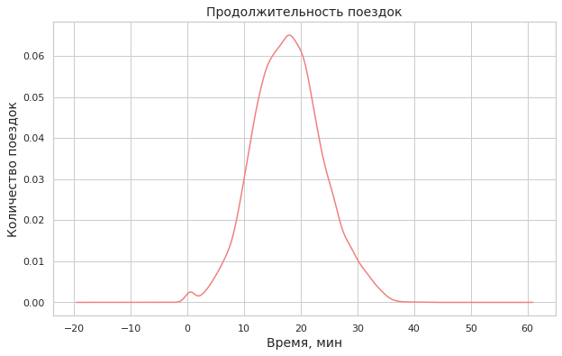

```python
plt.figure(figsize=(10, 6))

round(data_riders['duration'].sort_values(ascending=False), 1).plot.kde(color='lightcoral')

plt.title('Продолжительность поездок', fontsize=14)
plt.xlabel('Время, мин', fontsize=14)
plt.ylabel('Количество поездок', fontsize=14)
plt.grid(True, axis='both')

plt.show()
```

Таким образом, как уже было сказано ранее, **самый популярный** среди пользователей самокатов город - Пятигорск. **Самый непопулярный** - Москва. Тем не менее, значения по городам примерно одинаково распределены.

Пользователей с **бесплатным** тарифом - 54,4% от общего числа пользователей. Пользователей с **платной подпиской**, соответственно - 45,6% от общего числа пользователей.

**Возраст** пользователей колеблется в пределах от 12 до 43 лет. Наиболее часто встречаются пользователи в возрасте от 23 до 27 лет.

**Касаемо расстояния за одну поездку:** как правило, пользователи самокатов проезжают в среднем 3 км. Наиболее часто значения находятся в пределах от 2 до 5,5 км.

**Касаемо продолжительности поездок:** как правило, пользователи самокатов продолжают свою поездку в среднем 17,8 мин. Наиболее часто значения находятся в пределах от 10 до 25 мин.

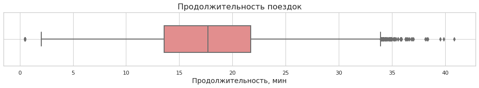

```python
plt.figure(figsize=(17, 2))
sns.boxplot(x=data_riders['duration'], color='lightcoral', width=0.5, linewidth=2)

# Добавляем заголовок и подписи к осям
plt.title('Продолжительность поездок', fontsize=16)
plt.xlabel('Продолжительность, мин', fontsize=14)
plt.ylabel('')

plt.grid(True, axis='both')

plt.show()
```

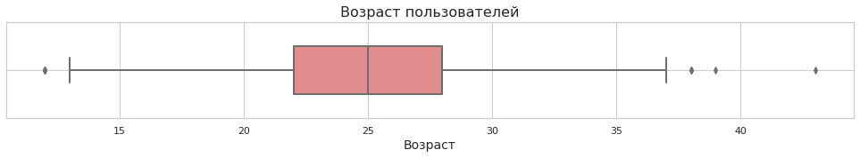

```python
plt.figure(figsize=(17, 2))
sns.boxplot(x=data_users['age'], color='lightcoral', width=0.5, linewidth=2)

# Добавляем заголовок и подписи к осям
plt.title('Возраст пользователей', fontsize=16)
plt.xlabel('Возраст', fontsize=14)
plt.ylabel('')

plt.grid(True, axis='both')

plt.show()
```

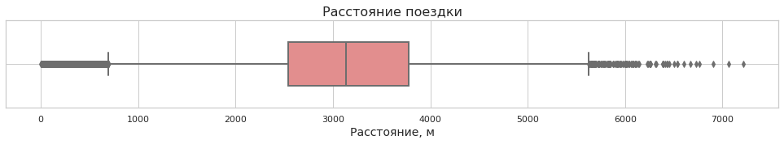

```python
plt.figure(figsize=(17, 2))
sns.boxplot(x=data_riders['distance'], color='lightcoral', width=0.5, linewidth=2)

# Добавляем заголовок и подписи к осям
plt.title('Расстояние поездки', fontsize=16)
plt.xlabel('Расстояние, м', fontsize=14)
plt.ylabel('')

plt.grid(True, axis='both')

plt.show()
```

Так, мы выяснили, что:

- большинство пользователей имеют возраст от 22 до 28 лет;
- большинство пользователей проезжают 2500-3800 метров;
- продолжительность поездки в основном составляет 14-22 минуты.

## Объединение данных

```python
data_users.shape
```

```
(1534, 5)
```

```python
data_riders.shape
```

```
(18068, 5)
```

```python
# данные о пользователях, поездках и подписках объединим в один датафрейм
data_2 = data_users.merge(data_riders)
data_2 = data_2.merge(data_sub)
#проверим
data_2.head(3)
```

|  | user_id | name | age | city | subscription_type | distance | duration | date | month | minute_price | start_ride_price | subscription_fee |
| --- | --- | --- | --- | --- | --- | --- | --- | --- | --- | --- | --- | --- |
| 0 | 1 | Кира | 22 | Тюмень | ultra | 4409.919140 | 25.599769 | 2021-01-01 | 1 | 6 | 0 | 199 |
| 1 | 1 | Кира | 22 | Тюмень | ultra | 2617.592153 | 15.816871 | 2021-01-18 | 1 | 6 | 0 | 199 |
| 2 | 1 | Кира | 22 | Тюмень | ultra | 754.159807 | 6.232113 | 2021-04-20 | 4 | 6 | 0 | 199 |

```python
#Проверим размерность таблицы после объединения
data_2.shape
```

```
(18068, 12)
```

```python
#Проверим наличие пропусков после объединения
data_2.isna().sum()
```

```
user_id              0
name                 0
age                  0
city                 0
subscription_type    0
distance             0
duration             0
date                 0
month                0
minute_price         0
start_ride_price     0
subscription_fee     0
dtype: int64
```

Таким образом, объединение таблиц было выполнено корректно, размерность таблицы "до" и "после" совпадает. Пропусков, как и предполагалась, в новой таблице (data_2) не обнаружено.

```python
# создадим датафрейм c данными о пользователях без подписки
without_sub = data_2.query("`subscription_type` == 'free'")

# создадим датафрейм c данными о пользователях с подпиской ultra
with_sub = data_2.query("`subscription_type` == 'ultra'")
#проверим
with_sub.sample(3)
without_sub.sample(3)
```

|  | user_id | name | age | city | subscription_type | distance | duration | date | month | minute_price | start_ride_price | subscription_fee |
| --- | --- | --- | --- | --- | --- | --- | --- | --- | --- | --- | --- | --- |
| 13977 | 1243 | Эдуард | 31 | Москва | free | 3173.808398 | 20.655841 | 2021-07-09 | 7 | 8 | 50 | 0 |
| 13871 | 1236 | Александр | 31 | Екатеринбург | free | 4097.416655 | 29.560357 | 2021-07-13 | 7 | 8 | 50 | 0 |
| 8536 | 851 | Нелли | 26 | Екатеринбург | free | 2727.111412 | 22.687620 | 2021-06-25 | 6 | 8 | 50 | 0 |

```python
#посмотрим размерность
without_sub.shape
```

```
(11568, 12)
```

```python
with_sub.shape
```

```
(6500, 12)
```

```python
# Проверим пропуски
datasets_2 = {'with_sub': with_sub, 'without_sub': without_sub}

for name, dataset in datasets_2.items():
    print(f"\033[1mНазвание датасета: {name}\033[0m")
    print(f"\033[1mПропуски в данных:\033[0m \n {dataset.isna().sum()}")
    print('*'*70)
```

```
Название датасета: with_sub
Пропуски в данных:
 user_id              0
name                 0
age                  0
city                 0
subscription_type    0
distance             0
duration             0
date                 0
month                0
minute_price         0
start_ride_price     0
subscription_fee     0
dtype: int64
Название датасета: without_sub
Пропуски в данных:
 user_id              0
name                 0
age                  0
city                 0
subscription_type    0
distance             0
duration             0
date                 0
month                0
minute_price         0
start_ride_price     0
subscription_fee     0
dtype: int64
```

Как мы видим, разделение таблицы на две другие было проведено корректно. Сумма размерностей двух новых таблиц равна 18068, что совпадает с размерностью исходной таблицы. Также совпадает и количество столбцов. Пропусков не обнаружено.

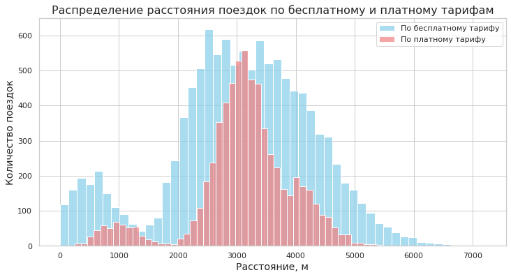

```python
plt.figure(figsize=(12, 6))

# График для бесплатного тарифа
sns.histplot(without_sub['distance'], bins=50, color='skyblue', alpha=0.7)

# График для платного тарифа
sns.histplot(with_sub['distance'], bins=50, color='lightcoral', alpha=0.7)

# Добавляем заголовок и подписи к осям
plt.title('Распределение расстояния поездок по бесплатному и платному тарифам', fontsize=16)
plt.xlabel('Расстояние, м', fontsize=14)
plt.ylabel('Количество поездок', fontsize=14)

plt.legend(['По бесплатному тарифу', 'По платному тарифу'])
plt.show()
```

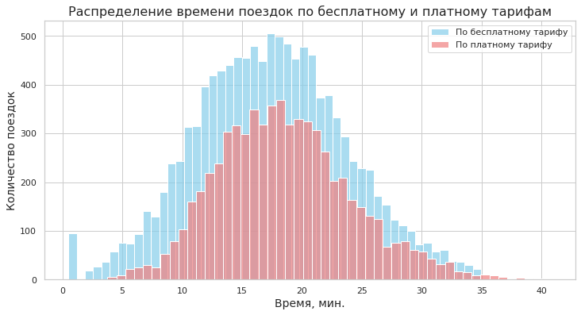

```python
plt.figure(figsize=(12, 6))

# График для бесплатного тарифа
sns.histplot(without_sub['duration'], bins=50, color='skyblue', alpha=0.7)

# График для платного тарифа
sns.histplot(with_sub['duration'], bins=50, color='lightcoral', alpha=0.7)

# Добавляем заголовок и подписи к осям
plt.title('Распределение времени поездок по бесплатному и платному тарифам', fontsize=16)
plt.xlabel('Время, мин.', fontsize=14)
plt.ylabel('Количество поездок', fontsize=14)
plt.legend(['По бесплатному тарифу', 'По платному тарифу'])

plt.show()
```

```python
#Добавим статистики
without_sub['distance'].describe()
```

```
count    11568.000000
mean      3045.495282
std       1246.173806
min          0.855683
25%       2366.562689
50%       3114.648465
75%       3905.697894
max       7211.007745
Name: distance, dtype: float64
```

```python
with_sub['distance'].describe()
```

```
count    6500.000000
mean     3115.445388
std       836.895330
min       244.210438
25%      2785.444017
50%      3148.637229
75%      3560.574425
max      5699.769662
Name: distance, dtype: float64
```

```python
without_sub['duration'].describe()
```

```
count    11568.000000
mean        17.390909
std          6.326803
min          0.500000
25%         12.958437
50%         17.326890
75%         21.594071
max         34.948498
Name: duration, dtype: float64
```

```python
with_sub['duration'].describe()
```

```
count    6500.000000
mean       18.541985
std         5.572048
min         3.760353
25%        14.524654
50%        18.178153
75%        21.884129
max        40.823963
Name: duration, dtype: float64
```

**Вывод по объединению данных:**

Расстояние, которое проезжают по **бесплатному тарифу**, в основном находится в пределах от 2 до 4,5 км. Пик - 2,5 км. Срднее = 3045 м., минимальное расстояние = 0.8 м.(возможно, самокат даже не смог тронуться), максимальное расстояние = 7211 м.

Время, которое тратят пользователи **бесплатного тарифа** находится в большинстве случаев в пределах от 5 до 30 минут. Среднее значение = 17.3 мин.,минимальное время = 0.5 мин, а максимальное = 34.9 мин.

Расстояние, которое проезжают по **тарифу Ultra**, в основном находится в пределах от 2 до 5 км. Самый пик - 3 км. Но есть множество и тех, кто проезжают всего 1 км. Среднее значение = 3115 м., минимальное расстояние = 244 м., а максимальное = 5699.7 м.

Время, которое тратят пользователи **платного тарифа** находится в большинстве случаев в пределах от 10 до 30 минут. Среднее значение = 18.5 мин., минимальное значение = 3.7 мин., а максимальное = 40.8 мин.

По времени в обоих случаях пик = примерно 17 мин.

## Подсчёт выручки

```python
#округляем до агрегации
data_2['duration'] = np.ceil(data_2['duration'])
#проверяем округление
data_2.sample(3)
```

|  | user_id | name | age | city | subscription_type | distance | duration | date | month | minute_price | start_ride_price | subscription_fee |
| --- | --- | --- | --- | --- | --- | --- | --- | --- | --- | --- | --- | --- |
| 15293 | 1338 | Эмиль | 25 | Екатеринбург | free | 3238.432503 | 19.0 | 2021-06-19 | 6 | 8 | 50 | 0 |
| 15042 | 1318 | Мадина | 28 | Москва | free | 2012.472113 | 12.0 | 2021-11-12 | 11 | 8 | 50 | 0 |
| 18010 | 1531 | Никита | 25 | Пятигорск | free | 3105.422413 | 14.0 | 2021-04-19 | 4 | 8 | 50 | 0 |

```python
# Создадим датафрейм с агрегированными данными о поездках
data_3 = pd.pivot_table(data_2, index=['month', 'user_id'],
                        values = ['distance', 'duration', 'name', 'subscription_type'],
                        aggfunc = {'distance': sum,
                                   'duration' : sum,
                                   'name' : len,
                                   'subscription_type' : min})
# отсортируем и проверим
data_3.sort_values(by='month').head()
```

| month | user_id | distance | duration | name | subscription_type |
| --- | --- | --- | --- | --- | --- |
| 1 | 1 | 7027.511294 | 42.0 | 2 | ultra |
|  | 1061 | 12637.249630 | 43.0 | 3 | free |
|  | 1063 | 3276.362299 | 10.0 | 1 | free |
|  | 1064 | 5297.324649 | 15.0 | 1 | free |
|  | 1065 | 14547.099333 | 99.0 | 4 | free |

```python
#переименуем столбец name
data_3.rename(columns = {'name' : 'number_of_trips'}, inplace = True)
#проверим таблицу
data_3.query('month == 4')
```

| month | user_id | distance | duration | number_of_trips | subscription_type |
| --- | --- | --- | --- | --- | --- |
| 4 | 1 | 754.159807 | 7.0 | 1 | ultra |
|  | 2 | 6164.381824 | 40.0 | 2 | ultra |
|  | 3 | 2956.651632 | 21.0 | 1 | ultra |
|  | 5 | 3373.080412 | 15.0 | 1 | ultra |
|  | 7 | 4888.946162 | 38.0 | 2 | ultra |
|  | ... | ... | ... | ... | ... |
|  | 1530 | 9846.644422 | 60.0 | 2 | free |
|  | 1531 | 13021.538366 | 80.0 | 4 | free |
|  | 1532 | 842.097458 | 9.0 | 1 | free |
|  | 1533 | 2514.498956 | 18.0 | 1 | free |
|  | 1534 | 3434.290912 | 15.0 | 1 | free |

927 rows × 4 columns

```python
#проверяем агрегированные данные на пропуски
data_3.isna().sum()
```

```
distance             0
duration             0
number_of_trips      0
subscription_type    0
dtype: int64
```

```python
# Добавляем столбец с помесячной выручкой
def money(i):
    minute_price_free = 8
    minute_price_ultra = 6
    start_ride_price = 50
    subscription_fee = 199

    if i['subscription_type'] == 'free':
        return minute_price_free * i['duration'] + start_ride_price * i['number_of_trips']
    elif i['subscription_type'] == 'ultra':
        return minute_price_ultra * i['duration'] + subscription_fee
    else:
        return 'Не указан тариф'
data_3['money_for_month'] = data_3.apply(money, axis=1)
data_3.sample(3)
```

| month | user_id | distance | duration | number_of_trips | subscription_type | money_for_month |
| --- | --- | --- | --- | --- | --- | --- |
| 9 | 616 | 2878.912319 | 19.0 | 1 | ultra | 313.0 |
| 4 | 1304 | 4130.780649 | 32.0 | 2 | free | 356.0 |
| 9 | 88 | 3011.480119 | 21.0 | 1 | ultra | 325.0 |

```python
data_3['money_for_month'].describe()
```

```
count    11331.000000
mean       342.303504
std        153.875346
min         58.000000
25%        234.000000
50%        319.000000
75%        415.000000
max       1444.000000
Name: money_for_month, dtype: float64
```

```python
data_3['number_of_trips'].describe()
```

```
count    11331.000000
mean         1.594564
std          0.831604
min          1.000000
25%          1.000000
50%          1.000000
75%          2.000000
max          7.000000
Name: number_of_trips, dtype: float64
```

```python
data_3['money_for_month'].sum()
```

```
3878641.0
```

**Вывод по подсчету выручки:**

- найдено суммарное расстояние, количество поездок и суммарное время для каждого пользователя за каждый месяц;
- добавлен столбец с помесячной выручкой, которую принёс каждый пользователь.
- наибольшаяя выручка от одного пользователя за месяц - 1444 руб., а наименьшая - 58 руб.;
- в среднем пользователи тратят 342 руб. на поездки на самокатах за месяц;
- наибольшее количество поездок 1 пользователя за месяц - 7 раз.